# FM-PreRegistration

# LOAD IN TIDYVERSE

```r
library(tidyverse)
```

# IMPORT DATA

```r
sona_data = read.csv("../data/savic-rhyming-sona.csv") %>%
  select(-sona_id) %>% mutate(data_source = "sona")


prolific_data = read.csv ("../data/savic-rhyming-prolific.csv") %>%
  select(-PROLIFIC_PID) %>% mutate(data_source = "prolific")
```

Making sure sona data and prolific data have the same amount of columns

```r
ncol(sona_data)
```

```
[1] 51
```

```r
ncol(prolific_data)
```

```
[1] 52
```

```r
prolific_data <- prolific_data %>% select(names(sona_data))
```

bind data from both sona and prolific

```r
##prolific_data <- prolific_data %>% select(names(sona_data))
final_data = rbind(sona_data, prolific_data) %>%
 mutate(rt = as.numeric(rt),
        relatedness = as.factor(relatedness),
        condition = as.factor(condition))%>%
  mutate(condition = fct_recode(condition,
                                "non-rhyming" = "1",
                               "rhyming" = "2")) %>%
  mutate(relatedness = fct_recode(relatedness,
                                  "related" = "unrelated",
                                  "unrelated" = "related")) %>%
 mutate(correct = tolower(correct))
```

# INSPECT DATA

```r
#number of rows and columns
nrow(final_data)
```

```
[1] 69105
```

```r
ncol(final_data)
```

```
[1] 51
```

## Unique subjects and trials

```r
#unique participants and trials

final_data%>%
group_by(ID)%>%
count()
```

| ID | n |
| --- | --- |
| 8298799 | 347 |
| 12054445 | 347 |
| 16777069 | 355 |
| 18075384 | 347 |
| 19865559 | 346 |
| 23547063 | 349 |
| 28359621 | 348 |
| 42712906 | 349 |
| 43108275 | 355 |
| 45837842 | 346 |

[output cut: 187 more lines]

```r
final_data %>%
  filter(typeoftrial == "sentence") %>%
  group_by(ID) %>%
  count()
```

| ID | n |
| --- | --- |
| 8298799 | 60 |
| 12054445 | 60 |
| 16777069 | 60 |
| 18075384 | 60 |
| 19865559 | 60 |
| 23547063 | 60 |
| 28359621 | 60 |
| 42712906 | 60 |
| 43108275 | 60 |
| 45837842 | 60 |

[output cut: 187 more lines]

60 sentence trials were completed all participants except four: 232084287, 467885230, 727137633, 869755378.

```r
final_data %>%
  filter(typeoftrial == "attention") %>%
  group_by(ID) %>%
  count()
```

| ID | n |
| --- | --- |
| 8298799 | 9 |
| 12054445 | 9 |
| 16777069 | 9 |
| 18075384 | 9 |
| 19865559 | 9 |
| 23547063 | 9 |
| 28359621 | 9 |
| 42712906 | 9 |
| 43108275 | 9 |
| 45837842 | 9 |

[output cut: 187 more lines]

9 attention check trials were completed by all participants except the same four: 232084287, 467885230, 727137633, 869755378.

```r
final_data %>%
  filter(typeoftrial == "target") %>%
  group_by(ID) %>%
  count()
```

| ID | n |
| --- | --- |
| 8298799 | 55 |
| 12054445 | 55 |
| 16777069 | 55 |
| 18075384 | 55 |
| 19865559 | 55 |
| 23547063 | 55 |
| 28359621 | 55 |
| 42712906 | 55 |
| 43108275 | 55 |
| 45837842 | 55 |

[output cut: 187 more lines]

All participants completeted 55 trials; however, these 4 subject IDs did not appear in the data because they had no target data.

## Columns and Levels of variables

```r
levels(final_data$condition)
```

```
[1] "non-rhyming" "rhyming"
```

```r
levels(final_data$relatedness)
```

```
[1] ""          "novel"     "unrelated" "related"
```

Our Condition and Relatedness columns indicate our independent variables. Condition has 2 levels: non-rhyming and rhyming Relatedness has 2 levels that we are evaluating (related and unrelated). In the data it has “novel” and “” too. No target trial has ““.

Our primary dependent variable columns are reaction time and correct for target trials. For our attention check and association task, we are looking at the response column.

#BASIC DESCRIPTIVES

```r
demographics = final_data %>%
  filter(typeoftrial == "demographics") %>%
  select("ID","gender", "age", "education", "race", "hispanic", "dominant_hand", "alert_time", "english")%>%
  mutate(across(c("age","education"), ~ replace_na(., NA)))%>%
 mutate(across(c("gender","race","hispanic","dominant_hand","alert_time","english"),
                 ~ replace_na(., "NOT_FOUND"))) %>%
mutate(across(c("age","gender","education","race","hispanic", "dominant_hand", "alert_time", "english"),
              ~ifelse(. == "", "blank",.)))

subject_age= demographics%>%
  summarise(mean_age= mean(age, na.rm = TRUE),
            sd_age=sd(age, na.rm = TRUE))

gender_distribution= demographics%>%
  filter(gender != "blank") %>%
  count(gender)

race_distribution= demographics%>%
  filter(race != "blank")%>%
  count(race)

education_distribution= demographics%>%
  filter(education != "blank")%>%
  summarise(mean_education= mean(education, na.rm = TRUE),
            sd_education=sd(education, na.rm = TRUE))
```

Mean age is 33.63 years old with a standard deviation of 14.70. (M = 33.63, SD = 14.70) Gender distribution: Women (n = 72), Men (n = 52), Nonbinary (n = 2) Race distribution: Asian (n = 6), Black/African American (n = 24), Other (n = 6), White/Caucasian (n = 82), Multiracial (n = 8) The mean education years is 14.65 with a standard deviation of 2.80 (M = 14.65, SD = 2.80).

## Average accuracy in your experiment and the standard deviation of the accuracy?

```r
trial_data = final_data %>%
  filter(typeoftrial == "target") %>%
  select(type, correct, block_number, target, correct_key) %>%
  filter(block_number == 1) %>%
  mutate(correct = fct_recode(correct,
                              "0" = "false",
                              "1" = "true")) %>%
  mutate(correct = as.numeric(as.character(correct)))

trial_accuracy = trial_data %>%
   summarise(mean_accuracy = mean(correct, na.rm = TRUE),
    sd_accuracy = sd(correct, na.rm = TRUE))
```

Average accuracy for target trials (not practice trials) with no exclusions (M = 0.87, SD = 0.34)

## Histogram of rt

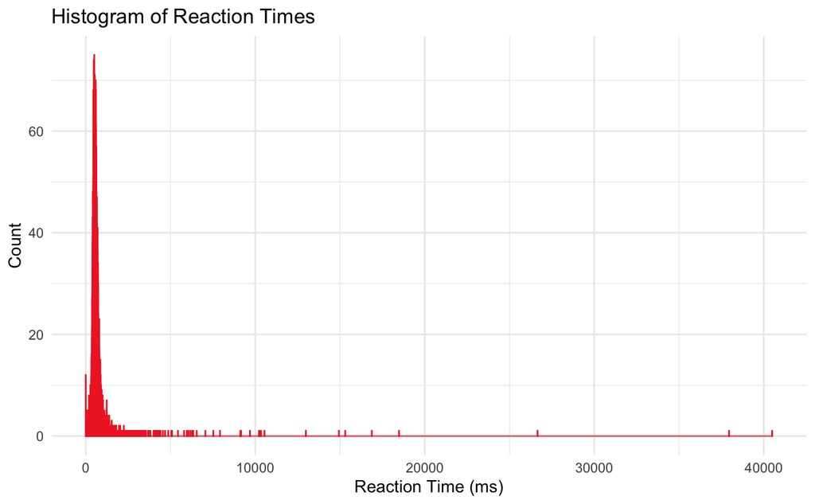

```r
basic_data = final_data %>%
  filter(typeoftrial == "target") %>%
  select(ID, rt, condition, relatedness, prime, response, type, correct, block_number, target, correct_key)

ggplot(basic_data, aes(x = rt)) +
  geom_histogram(binwidth = 2, color = "firebrick2") +
  theme_minimal() +
  labs(title = "Histogram of Reaction Times", x = "Reaction Time (ms)", y = "Count")
```

```r
geom_histogram(mapping = aes (x = as.numeric(rt)))
```

```
mapping: x = ~as.numeric(rt)
geom_bar: na.rm = FALSE, orientation = NA
stat_bin: binwidth = NULL, bins = NULL, na.rm = FALSE, orientation = NA, pad = FALSE
position_stack
```

Our histogram has concentrated reaction times under 2 seconds. From our data being displayed in this way, we can determine that we definitely will have outliers as some values are well over 1500 ms.

## Exclusions

We excluded data from participants whose accuracy on attention check questions was less than 0.75. On the priming task, incorrect identification of the familiar noun or reaction times that are extremely short (less than 200 ms) or extremely long (greater than 1,500 ms) will result in removal of data. In addition, incomplete experiments will be removed from analyses. Finally, English fluency is necessary, so data will be removed if a participant’s first language is not English or they did not learn before the age of 4.

```r
#editing all attention trials to adjust for typos
attention_trials= final_data%>%
  filter(typeoftrial == "attention") %>%
  select(ID, response, novel1, novel2, correct) %>%
    rowwise() %>%
  mutate(response = ifelse(is.na(response), "blank", response)) %>%
  mutate(across(c(novel1, novel2), ~ replace_na(., "NOT_FOUND"))) %>%
  mutate(edit_novel1 = adist(novel1, response),
         edit_novel2 = adist(novel2, response)) %>%
  mutate(revised_correct = ifelse(edit_novel1 <= 2 |
                                    edit_novel2 <= 2,
                                    1, 0),
          mismatch = ifelse(correct == revised_correct, 0, 1)) %>%
  ungroup()

## summarize participant accuracy on attention trials
subject_attention_accuracy = attention_trials  %>%
  group_by(ID)  %>%
  summarise(mean_accuracy = mean(revised_correct))

# find IDs with less than 75% accuracy
low_acc_IDs = subject_attention_accuracy  %>%
  filter(mean_accuracy < 0.75)  %>%
  pull(ID)
```

```r
#target data after applying exclusions

priming_data = final_data %>%
  filter(typeoftrial == "target") %>%
  select (ID, rt, condition, relatedness, prime, response, type, correct, block_number, target, correct_key) %>%
  filter(!is.na(rt), rt> 200 , rt< 1500, correct == "true", block_number == 1) %>%
  filter(relatedness %in% c("related", "unrelated")) %>%
  filter(!ID %in% low_acc_IDs)

priming_accuracy = priming_data %>%
  mutate(acc = ifelse(correct == "true", 1,0)) %>%
  group_by(ID) %>%
  summarize(acc = mean(acc))

counts = final_data %>%
  group_by(condition, relatedness)%>%
  count()
```

```r
priming_data%>%
  group_by(condition, ID)%>%
  count()%>%
  group_by(condition)%>%
  count()
```

| condition | n |
| --- | --- |
| non-rhyming | 70 |
| rhyming | 67 |

- how many participants were recruited = 225
- how many did not finish the game = 28
- how many were excluded based on ALL pre-registered criteria = 60
- how many participants’ data are analyzed for priming: 137 participants’ data are analyzed in our priming model (70 non-rhyming and 67 rhyming)

## bar plot

### bar data

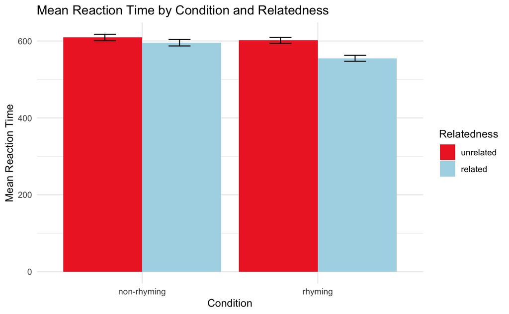

```r
# Summarise the data and directly use it in the plotting step
mean_scores = priming_data %>%
  group_by(condition, relatedness) %>%
  summarise(mean_rt = mean(rt, na.rm = TRUE),
          sd_rt = sd(rt, na.rm = TRUE)) %>%
  left_join(counts)%>%
  mutate(SE = sd_rt/sqrt(n),
         ymin = mean_rt - 1.96*SE,
          ymax = mean_rt + 1.96*SE)
mean_scores %>%
  ggplot(mapping = aes(x = condition, y = mean_rt, group = relatedness, fill = relatedness)) +
  geom_col(position = "dodge") +
  geom_errorbar(
    aes(ymin = ymin, ymax = ymax),
    width = 0.25,
    position = position_dodge(width = .85)) +
  theme_minimal() +
  scale_fill_manual(values = c("firebrick2", "lightblue")) +
  labs(
    title = "Mean Reaction Time by Condition and Relatedness",
    x = "Condition",
    y = "Mean Reaction Time"
  ) +
  guides(fill = guide_legend(title = "Relatedness"))
```

#Inferential Statistics

Inspecting the model

```r
#install.packages("lmerTest")
library(lmerTest)
library(performance)

rt_model = lmer(data = priming_data, rt~ relatedness*condition + (1|ID))
```

```r
car::Anova(rt_model)
```

```
Analysis of Deviance Table (Type II Wald chisquare tests)

Response: rt
                        Chisq Df Pr(>Chisq)
relatedness           37.1611  1  1.088e-09 ***
condition              3.1053  1  0.0780382 .
relatedness:condition 13.1753  1  0.0002837 ***
---
Signif. codes:  0 ‘***’ 0.001 ‘**’ 0.01 ‘*’ 0.05 ‘.’ 0.1 ‘ ’ 1
```

```r
nobs(rt_model)
```

```
[1] 3796
```

```r
print(nobs(rt_model))
```

```
[1] 3796
```

[figure not shown]

```r
check_model(rt_model)
```

Our primary research question is whether exposure to language containing rhyming words can help to foster semantic links between novel and familiar words. If rhyming facilitates semantic integration, participants should identify familiar nouns faster when the prime is related to and rhymes with the familiar noun.

The model revealed a significant main effect of relatedness (χ² (1, N = 3796)= 37.16, p < 0.001), suggesting that relatedness significantly influenced reaction times. The effect of condition was not significant (χ² = (1, N = 3796) = 3.11, p = 0.078),suggesting a potential influence of condition. The significant interaction between relatedness and condition (χ² = (1, N = 3796) = 13.18, p < 0.001) suggests that the effect of relatedness on reaction time is moderated by the condition.